# TFG Análisis de Parámetros de Calidad

Sergio Escalante

5/2/2021

# Resumen

Se montó un ensayo para evaluar el efecto de tecnologías digitales en la gestión de riego de un cultivo de sandía en el cantón de Nicoya, Guanacaste. El tratamiento tuvo instalado durante el ciclo un sensor de humedad inteligente marca CropX que facilitó al equipo de producción data para decidir y prioritizar riegos en la finca. El testigo recibió el mismo manejo que siempre se ha dado en la finca. El día de la cosecha se recogieron 15 frutos distribuidos aleatoramente en cada tratamiento. Los puntos de muestreo fueron generados con una herramienta aleatorizante del software de sistemas de información geográfica QGIS. Los fruto se llevaron a la planta y fueron evaluados en diferentes parámetros: °Brix, peso (kg), circumferencia (cm).

# El conjunto de datos usados para describir calidad

```r
# Incluye la primera y segunda siembra, el muestreo de la segunda siembra se hizo en la cosecha del lote 22-1 pero 4 días antes de la cosecha del 22-2

cropx = data.frame(tratamiento = as.factor(rep("CropX",30)),
        lote = as.factor(rep("22-1",30)),
        siembra = as.factor(c(rep(1,15),rep(2,15))),
        circ.cm = c( 61,61.5,63.5,63,55,59,63,70,64,58.5,60.5,66,63,55,60,
                    60,58.5,60,63,63,58,60,60,65,55,67,63,65,57,58.5),


        peso.kg = c(3.3,3.96,4.62,4.54,3.2,3.8,4.3,5.85,4.73,3.47,3.35,5.14,4.53,2.94,3.83,
                   3.48,3.41,4.06,4.56,4.36,3.68,3.88,3.76,4.61,2.99,5.12,5.05,4.7,3.48,3.53),

        brix = c(10,11,11,11,10,9,10,11.5,10.3,9.5,10,10.5,12,10,9,
                10,9,11.3,11.6,10.7, 9, 9,10.7, 10.9,10.3,10.7,10.2,11,10.3,10.3)
                                )

testigo = data.frame(tratamiento = as.factor(rep("Testigo",30)),
                   lote = as.factor(rep("22-2",30)),
                   siembra = as.factor(c(rep(1,15),rep(2,15))),
                   circ.cm = c(58,59,59,60.5,66.5,58,57,62.6,59.8,64,65.2,62,63.6,58.4,64.4,
                               56,55,52,54,57,52.5,55,59,55,57,56,48.5,49,53.5,50),
                   peso.kg = c(3.56,3.51,3.595,3.82,5.34,3.395,3.32,4.595,3.77,4.68,4.67,4.545,4.835,4.025,4.765,                          3.06,2.98,2.6,2.68,3.44,2.55,3.09,3.65,2.8,3.3,3.23,2.3,2.24,2.66,2.48),
                   brix = c(11, 10.6, 10.2, 11.2,11,10,9.4,10.4,11.2,10.8,11,11.2,10,10.8,11.6,
                            10.2,9,8.6,9.3,9.6,9.8,8.6,8.7,9.6,10.1,10.2,9.0,8.9,8.2,8.7)
                                )

data_tfg = rbind(cropx,testigo)

rm(cropx, testigo)
```

```r
yl_circ <- c(44,75)    # Estos es para fijar después los ejes de los gráficos para los parámetros evaluados
yl_kg <- c(1.8, 6)
yl_brix <- c(7,12)
```

Se realizan pruebas de normalidad(Shapiro-Wilks) y homocedasticidad(Levene) para evaluar si los resultados de una prueba-T son aceptables:

```r
library(rstatix)
#data_tfg$lote <- as.integer(data_tfg$lote)
#data_tfg$siembra <- as.integer(data_tfg$siembra)
data_tfg <- data_tfg %>% pivot_longer(c(-tratamiento,-lote,-siembra), names_to = "parametro", values_to = "valor")


levene_ <- data_tfg %>% group_by(parametro,siembra) %>%
        levene_test(valor~tratamiento)

shapiro_ <- data_tfg %>% group_by(parametro,siembra) %>%
        shapiro_test(valor)


kable(levene_)
```

| siembra | parametro | df1 | df2 | statistic | p |
| --- | --- | --- | --- | --- | --- |
| 1 | brix | 1 | 28 | 1.1359538 | 0.2956135 |
| 2 | brix | 1 | 28 | 0.1559367 | 0.6959175 |
| 1 | circ.cm | 1 | 28 | 0.1497674 | 0.7016836 |
| 2 | circ.cm | 1 | 28 | 0.0873885 | 0.7697049 |
| 1 | peso.kg | 1 | 28 | 0.3997407 | 0.5323525 |
| 2 | peso.kg | 1 | 28 | 2.9266738 | 0.0981861 |

```r
kable(shapiro_)
```

| siembra | parametro | variable | statistic | p |
| --- | --- | --- | --- | --- |
| 1 | brix | valor | 0.9614115 | 0.3364379 |
| 2 | brix | valor | 0.9548014 | 0.2268879 |
| 1 | circ.cm | valor | 0.9809338 | 0.8498090 |
| 2 | circ.cm | valor | 0.9798773 | 0.8222813 |
| 1 | peso.kg | valor | 0.9540436 | 0.2166619 |
| 2 | peso.kg | valor | 0.9530516 | 0.2039277 |

Los datos presentan normalidad y homocedasticidad. Adicionalmente, su selección fue aleatoria y se asume la aditividad. Estos son los resultados de la prueba-T para los tres parámetros:

```r
stats_1s <- data_tfg %>%
  group_by(parametro,siembra) %>%
  t_test(valor~tratamiento,
         var.equal = T,
         conf.level = 0.9,
         detailed = F) %>%
  add_significance()


kable(stats_1s)
```

| siembra | parametro | .y. | group1 | group2 | n1 | n2 | statistic | df | p | p.signif |
| --- | --- | --- | --- | --- | --- | --- | --- | --- | --- | --- |
| 1 | brix | valor | CropX | Testigo | 15 | 15 | -1.3888838 | 28 | 1.76e-01 | ns |
| 2 | brix | valor | CropX | Testigo | 15 | 15 | 4.1094356 | 28 | 3.13e-04 | *** |
| 1 | circ.cm | valor | CropX | Testigo | 15 | 15 | 0.2614486 | 28 | 7.96e-01 | ns |
| 2 | circ.cm | valor | CropX | Testigo | 15 | 15 | 5.8821333 | 28 | 2.50e-06 | **** |
| 1 | peso.kg | valor | CropX | Testigo | 15 | 15 | -0.2162916 | 28 | 8.30e-01 | ns |
| 2 | peso.kg | valor | CropX | Testigo | 15 | 15 | 5.8634190 | 28 | 2.60e-06 | **** |

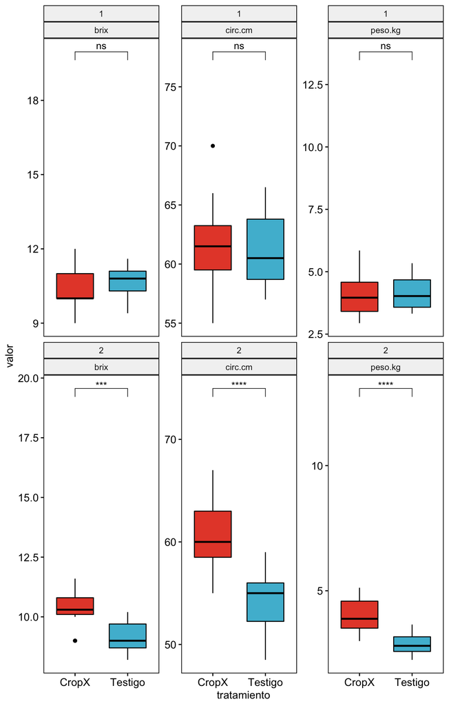

```r
myplot <- ggboxplot(
  data_tfg, x = "tratamiento", y = "valor",
  fill = "tratamiento", palette = "npg", legend = "none",
  ggtheme = theme_pubr(border = TRUE)
  ) +
  facet_wrap(siembra~parametro, scales = "free_y")


# Add statistical test p-values
stats_1s <- stats_1s %>% add_xy_position(x = "tratamiento")
myplot + stat_pvalue_manual(stats_1s, label = "p.signif")
```

# Nueva información

```r
qty <- read.csv("datos_calidad.csv")

## La calidad se analizó en un apartado anterior, incluyendo la evaluación de diagnósticos para ## pruebas de hipótesis (normalidad, homocedasticidad, aleatoriedad)

    qty$tratamiento <- as.factor(qty$tratamiento)
    qty$lote <- as.factor(qty$lote)
    qty$siembra <- as.factor(qty$siembra)
    qty <- qty %>% pivot_longer(c(circ.cm,peso.kg,brix), names_to = "parametro", values_to = "valor")
    qty$parametro <- as.factor(qty$parametro)
```

```r
#detach(package:plyr)
library(dplyr)

icm <- read.delim("tfg_ingresos_brutos.csv")
    icm$Tratamiento <- as.factor(icm$Tratamiento)
    icm$Calibre <- as.factor(icm$Calibre)
    icm$Cajas.10.kg <- as.integer(icm$Cajas.10.kg)
icm %>% group_by(Tratamiento, Siembra) %>%
                            summarise(cajas.ha = sum(Cajas.ha), ingresos.ha = scales::dollar(sum(Venta.ha))) %>%
                            filter(Tratamiento %in% c("CropX","Testigo"))
```

```
## # A tibble: 4 x 4
## # Groups:   Tratamiento [2]
##   Tratamiento Siembra cajas.ha ingresos.ha
##   <fct>         <int>    <int> <chr>
## 1 CropX             1     2412 $21,455.30
## 2 CropX             2     2796 $24,702.70
## 3 Testigo           1     3641 $32,339.90
## 4 Testigo           2     2207 $19,499
```

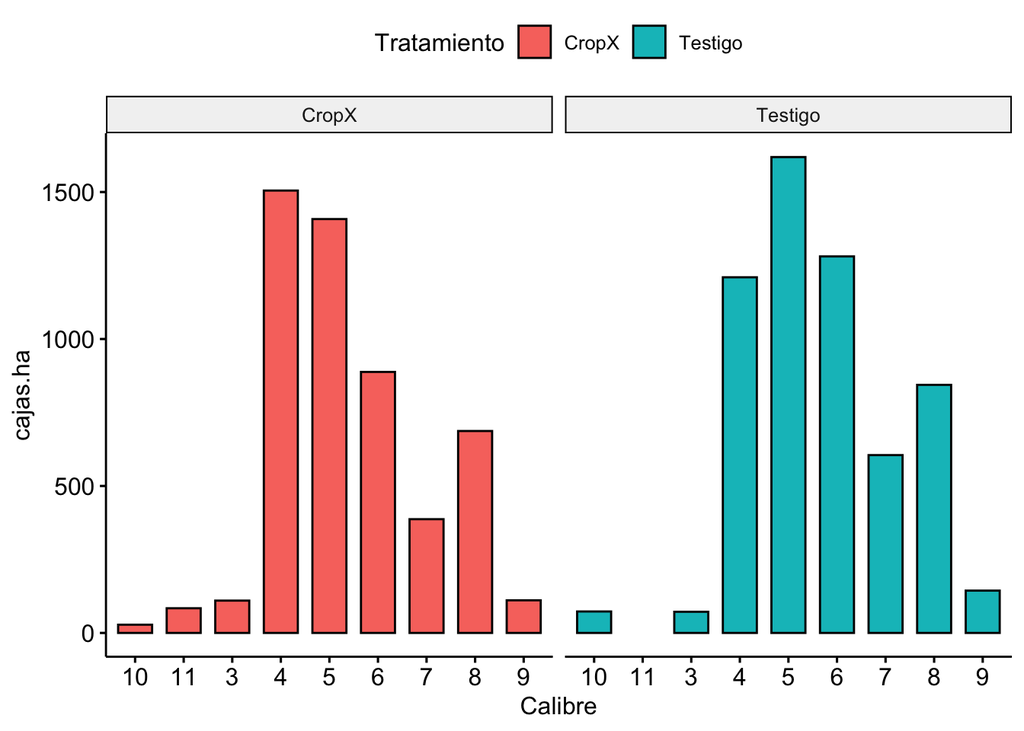

```r
icm %>% group_by(Tratamiento, Calibre) %>%
                            summarise(cajas.ha = sum(Cajas.ha), ingresos.ha = scales::dollar(sum(Venta.ha))) %>%
                            filter(Tratamiento %in% c("CropX","Testigo")) %>% ggbarplot(x="Calibre", y="cajas.ha", fill="Tratamiento")+facet_grid(cols=vars(Tratamiento))
```

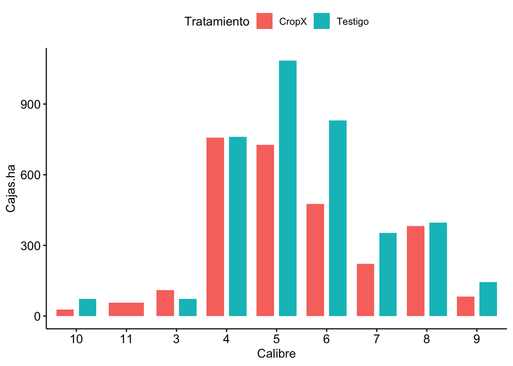

```r
icm %>% filter(Tratamiento %in% c("CropX","Testigo")) %>% ggbarplot(x="Calibre", y="Cajas.ha", fill="Tratamiento", position = position_dodge(0.9), color = FALSE)
```

```r
icm %>% group_by(Tratamiento) %>%
                            summarise(cajas.ha = sum(Cajas.ha),ingresos.ha = scales::dollar(sum(Venta.ha))) %>%filter(Tratamiento %in% c("CropX","Testigo"))
```

```
## # A tibble: 2 x 3
##   Tratamiento cajas.ha ingresos.ha
##   <fct>          <int> <chr>
## 1 CropX           5208 $46,158
## 2 Testigo         5848 $51,838.90
```

```r
ims <- read.delim("tfg_insumos_materiales.csv")
    ims$Fecha <- dmy(ims$Fecha)
    ims$Siembra <- as.factor(ims$Siembra)
    ims <- ims %>% mutate(Tratamiento = as.factor(if_else(Lote == "22-1","CropX","Testigo")))
    ims <- ims %>% mutate(Area.lote = if_else(Lote == "22-1",3.25,2.5))

ims_table <- ims %>% group_by(Tratamiento, Siembra) %>% summarise(debitos.ha = scales::dollar(sum((Débitos/Area.lote)/615)))
ims_table <- ims %>% group_by(Tratamiento) %>% summarise(debitos.ha = scales::dollar(sum((Débitos/Area.lote)/615)))

ims_table
```

```
## # A tibble: 2 x 2
##   Tratamiento debitos.ha
##   <fct>       <chr>
## 1 CropX       $2,805.64
## 2 Testigo     $2,622.98
```

```r
mh <- read.delim("tfg_mano_de_obra.csv")
    mh$Fecha <- dmy(mh$Fecha)
    mh$Lote <- as.factor(mh$Lote)
    mh <- mh %>% mutate(Tratamiento = if_else(Lote == "22-1", "CropX","Testigo"))
    mh$Grupo <- as.factor(mh$Grupo)
    mh$Actividad <- as.factor(mh$Actividad)

mh %>% group_by(Tratamiento,Siembra) %>% summarise(consumo.ha = scales::dollar(sum(Total.consumo.ha)/615))
```

```
## # A tibble: 4 x 3
## # Groups:   Tratamiento [2]
##   Tratamiento Siembra consumo.ha
##   <chr>         <int> <chr>
## 1 CropX             1 $1,445.28
## 2 CropX             2 $699.21
## 3 Testigo           1 $1,088.43
## 4 Testigo           2 $751.50
```

```r
mh %>% group_by(Tratamiento) %>% summarise(consumo.ha = scales::dollar(sum(Total.consumo.ha)/615))
```

```
## # A tibble: 2 x 2
##   Tratamiento consumo.ha
##   <chr>       <chr>
## 1 CropX       $2,144.49
## 2 Testigo     $1,839.93
```

```r
library(pivottabler)

mh_pvt <- mh %>%  qhpvt("Actividad", columns = c("Tratamiento", "Siembra"), "scales::dollar(sum(Total.consumo.ha)/615)")
mh_pvt
```

[interactive chart not shown]

```r
### Ahora eliminar actividades que no son parte del ensayo

mh_pvt <- mh %>% filter(Actividad %in% c("Acarreo Fruta","Acarreos de Insumos", "Ayudante Spray foliares","Control tamaños de fruta","Control Cuaje Fruta","Cosecha","Fumigacion Spray Fitosanitarios","Fumigación con Bomba Espalda", "Fumigación con Manguera","Plagueos","Recolección Fruta", "Retrasplante", "Retrasplante", "Riego y Fertilización","Trasplante"))%>%  qhpvt("Actividad", columns = c("Tratamiento", "Siembra"), "scales::dollar(sum(Total.consumo.ha)/615)")
mh_pvt
```

[interactive chart not shown]

```r
ms_ch <- read.delim("tfg_muestreos_cosecha.csv", sep = ";")

    ms_ch$Fecha <- dmy(ms_ch$Fecha)
    ms_ch$tipo.daño <- as.factor(ms_ch$tipo.daño)
    ms_ch <-  ms_ch %>% mutate(Tratamiento = if_else(Lote == "22-1", "CropX", "Testigo"),Year = if_else(Fecha < "2020-11-1", 2020, 2021))

    ## Vamos a dejar por fuera los datos de muestreo de cosecha del 12 de enero del 2021 y usar los de la fecha que se acerca a la cosecha (21-1-2021). De esta manera se puede hacer una prueba t para ver diferencias entre tratamientos y entre los dos años.

    ms_ch2 <- ms_ch %>% filter(Fecha != "2021-01-12")

levene_ <- ms_ch2 %>% group_by(Year) %>% levene_test(frutas.10m~Tratamiento)
shapiro_ <- ms_ch2 %>% group_by(Year) %>%
        shapiro_test(frutas.10m)


kable(levene_)
```

| Year | df1 | df2 | statistic | p |
| --- | --- | --- | --- | --- |
| 2020 | 1 | 38 | 4.767632 | 0.0352442 |
| 2021 | 1 | 43 | 4.038317 | 0.0507804 |

```r
kable(shapiro_)
```

| Year | variable | statistic | p |
| --- | --- | --- | --- |
| 2020 | frutas.10m | 0.9439007 | 0.0468776 |
| 2021 | frutas.10m | 0.9496799 | 0.0493966 |

```r
    stats_ms <- ms_ch2 %>%
      group_by(Year)%>%
      t_test(frutas.10m~Lote,
         var.equal = T,
         conf.level = 0.9,
         detailed = F) %>%
      add_significance()
    stats_ms <- stats_ms %>% add_xy_position(x = "Year");stats_ms
```

```
## # A tibble: 2 x 15
##    Year .y.       group1 group2    n1    n2 statistic    df           p p.signif
##   <dbl> <chr>     <chr>  <chr>  <int> <int>     <dbl> <dbl>       <dbl> <chr>
## 1  2020 frutas.1… 22-1   22-2      20    20     -6.92    38     3.13e-8 ****
## 2  2021 frutas.1… 22-1   22-2      24    21     -1.69    43     9.85e-2 ns
## # … with 5 more variables: y.position <dbl>, groups <named list>, x <dbl>,
## #   xmin <dbl>, xmax <dbl>
```

```r
        stats_ms2 <- ms_ch2 %>% filter(Year == 2021) %>%
          t_test(frutas.10m~Tratamiento,
             var.equal = T,
             conf.level = 0.9,
             detailed = F) %>%
          add_significance()
        stats_ms2 <- stats_ms2 %>% add_xy_position(x = "Tratamiento");stats_ms
```

```
## # A tibble: 2 x 15
##    Year .y.       group1 group2    n1    n2 statistic    df           p p.signif
##   <dbl> <chr>     <chr>  <chr>  <int> <int>     <dbl> <dbl>       <dbl> <chr>
## 1  2020 frutas.1… 22-1   22-2      20    20     -6.92    38     3.13e-8 ****
## 2  2021 frutas.1… 22-1   22-2      24    21     -1.69    43     9.85e-2 ns
## # … with 5 more variables: y.position <dbl>, groups <named list>, x <dbl>,
## #   xmin <dbl>, xmax <dbl>
```

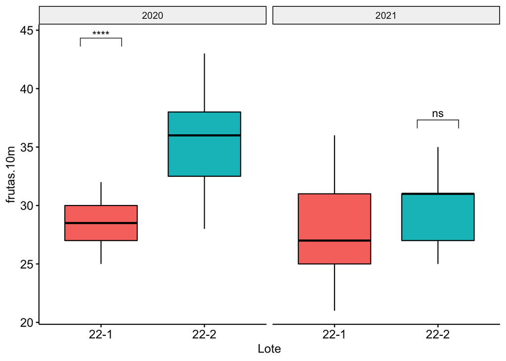

```r
plotch <- ms_ch2 %>% ggboxplot(x="Lote", y="frutas.10m", fill="Lote", pallette = "npg", legend = "none")+facet_wrap(vars(Year))+stat_pvalue_manual(stats_ms, label = "p.signif");plotch
```

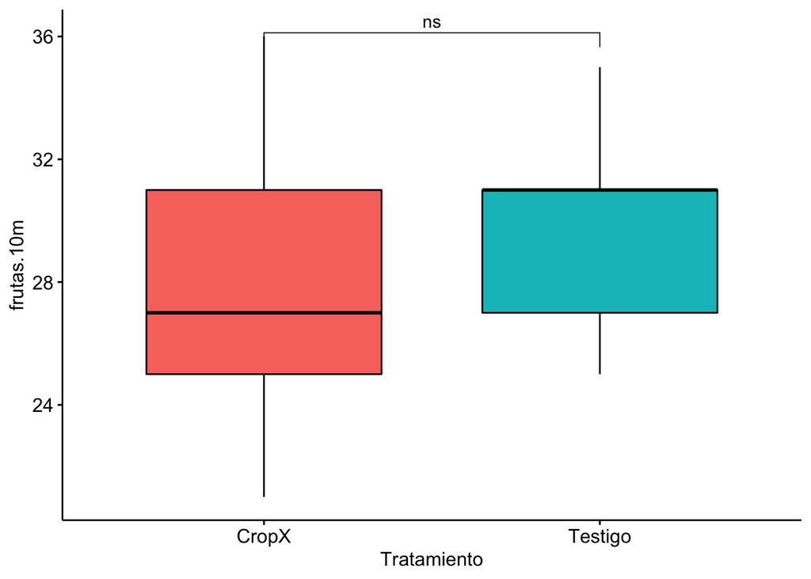

```r
 ms_ch2 %>% filter(Year == 2021) %>% ggboxplot(x="Tratamiento", y="frutas.10m", fill="Lote", pallette = "npg", legend = "none")+stat_pvalue_manual(stats_ms2, label = "p.signif")
```

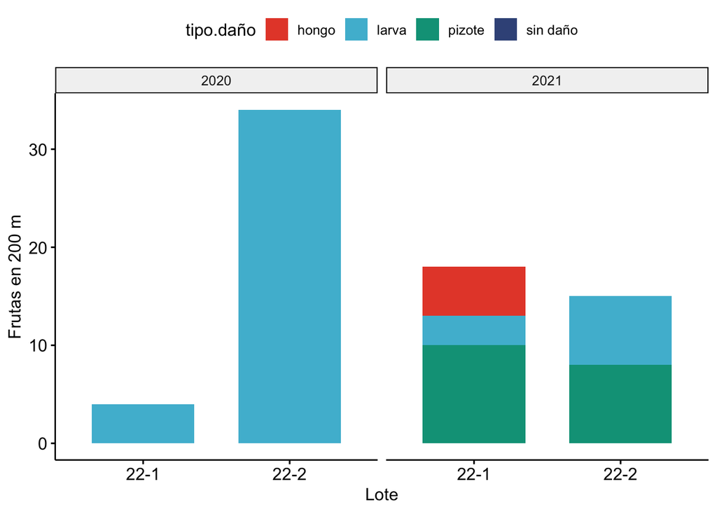

```r
ms_ch2 %>% ggbarplot(x="Lote", y="fruta.daño", color = FALSE, fill="tipo.daño", palette = "npg")+facet_wrap(vars(Year))+ylab("Frutas en 200 m")
```

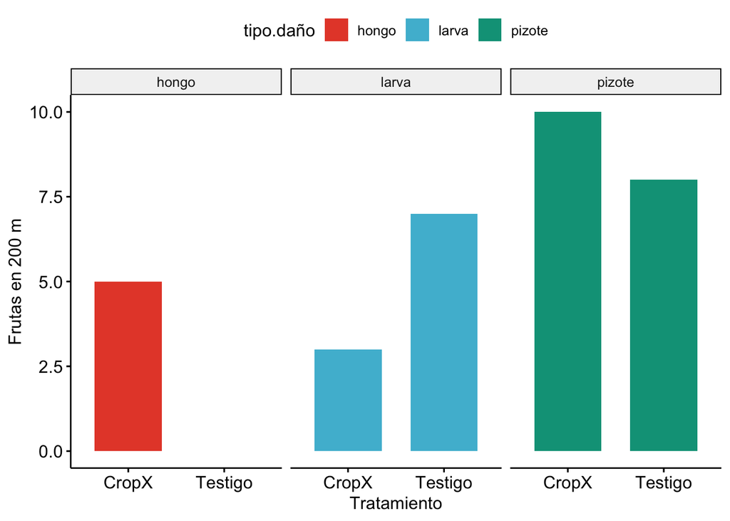

```r
ms_ch2 %>% filter(Year == 2021, tipo.daño != "sin daño") %>% ggbarplot(x="Tratamiento", y="fruta.daño", color = FALSE, fill="tipo.daño", palette = "npg")+facet_wrap(vars(tipo.daño))+ylab("Frutas en 200 m")
```

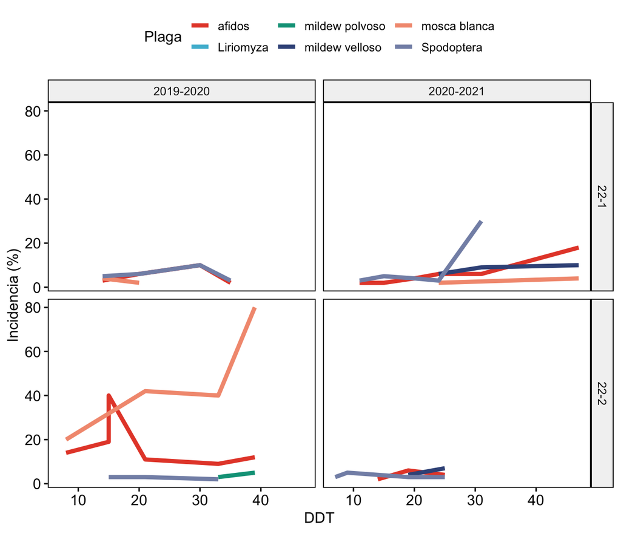

```r
plg <- read.delim("tfg_plagueos.csv", sep = ";")
    plg <- rename(plg, incidencia=incidencia...)
    plg$fecha <- dmy(plg$fecha)
    plg$Plaga <- as.factor(plg$Plaga)
    plg$Muestreo <- as.factor(plg$Muestreo)
    plg$lote <- as.factor(plg$lote)
    plg$incidencia <- as.integer(plg$incidencia)
    plg <- plg %>% mutate(Temporada = as.factor(if_else(fecha>="2020-11-11","2020-2021","2019-2020")))
    plg <- plg %>% mutate(Tratamiento = if_else(lote == "22-1","CropX","Testigo"))
    plg <- plg %>% mutate(lot.season = paste(lote,"ss-",Temporada))

    ## Se escogieron plagas que tuvieron la mayor incidencia para obtener figuras claras

plg %>% filter(Plaga %in% c("Spodoptera","afidos", "mosca blanca", "Liriomyza", "mildew velloso", "mildew polvoso"),  Muestreo == "Planta")%>% ggline(x="ddt",y="incidencia", col = "Plaga", palette = "npg", ggtheme = theme_pubr(border = TRUE), plot_type = "l", size = 1.618) + facet_grid(cols = vars(Temporada), rows = vars(lote)) + ylab("Incidencia (%)") + xlab("DDT")
```

```r
library(stringr)
area.221 <- 3.25
area.222 <- 2.5
rgo <- read.delim("tfg_registros_riego.csv")
    rgo_tfg <- rgo %>% filter(Tratamiento %in% c("CropX","Testigo")) %>% group_by(Siembra, Tratamiento) %>% mutate(cum.m3 = cumsum(m3.ha), area.lote.ha = if_else(Tratamiento == "CropX", 3.25,2.5))

    kable( rgo_tfg %>% group_by(Siembra,Tratamiento) %>% summarise(m3.total = sum(Volumen..m3.), m3.ha.total = as.integer(sum(m3.ha)), horas.riego = as.integer((sum(Volumen..m3.)/((mean(area.lote.ha)*10000)/(1.7*0.3*1000))))))
```

| Siembra | Tratamiento | m3.total | m3.ha.total | horas.riego |
| --- | --- | --- | --- | --- |
| 1 | CropX | 5040 | 1550 | 79 |
| 1 | Testigo | 4220 | 1688 | 86 |
| 2 | CropX | 7080 | 2178 | 111 |
| 2 | Testigo | 5150 | 2060 | 105 |

```r
    kable( rgo_tfg %>% group_by(Tratamiento) %>% summarise(m3.total = sum(Volumen..m3.), m3.ha.total = as.integer(sum(m3.ha)), horas.riego = as.integer((sum(Volumen..m3.)/((mean(area.lote.ha)*10000)/(1.7*0.3*1000))))) %>% mutate( costo.m3.ha = scales::dollar(m3.ha.total*0.003)))
```

| Tratamiento | m3.total | m3.ha.total | horas.riego | costo.m3.ha |
| --- | --- | --- | --- | --- |
| CropX | 12120 | 3729 | 190 | $11.19 |
| Testigo | 9370 | 3748 | 191 | $11.24 |

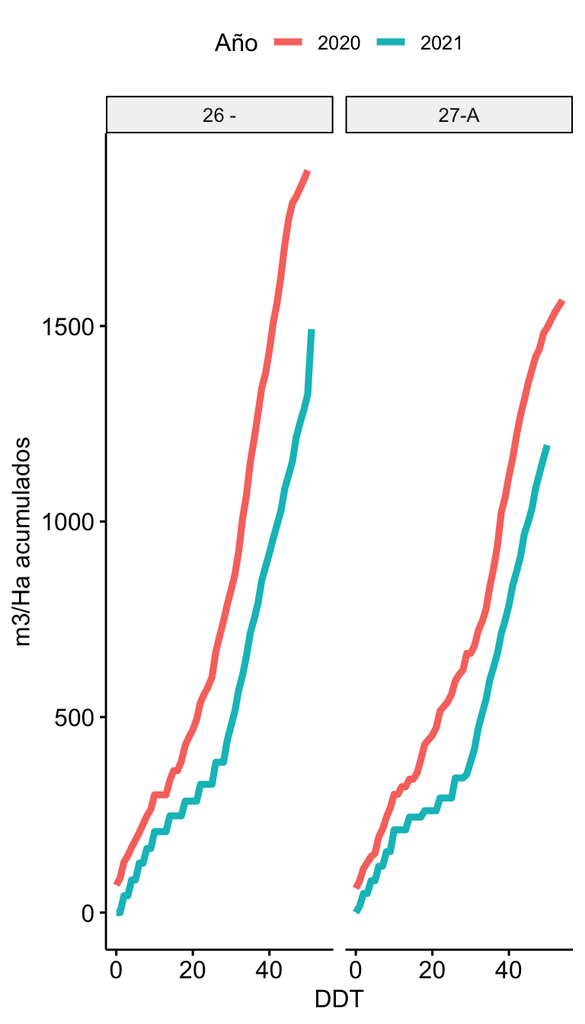

```r
    rgo_other <- rgo %>% filter(Tratamiento %in% c("27-A-2020","27-A-2021","26 - 2020", "26 - 2021")) %>% group_by(Tratamiento) %>% mutate(cum.m3 = cumsum(m3.ha), Año=str_sub(Tratamiento, -4,-1), lote=str_sub(Tratamiento,1,4))

    rgo_other %>% ggline(x="DDT", y="cum.m3",col = "Año",plot_type = "l", size = 1.618)+facet_grid(cols =vars(lote))+ylab("m3/Ha acumulados")
```

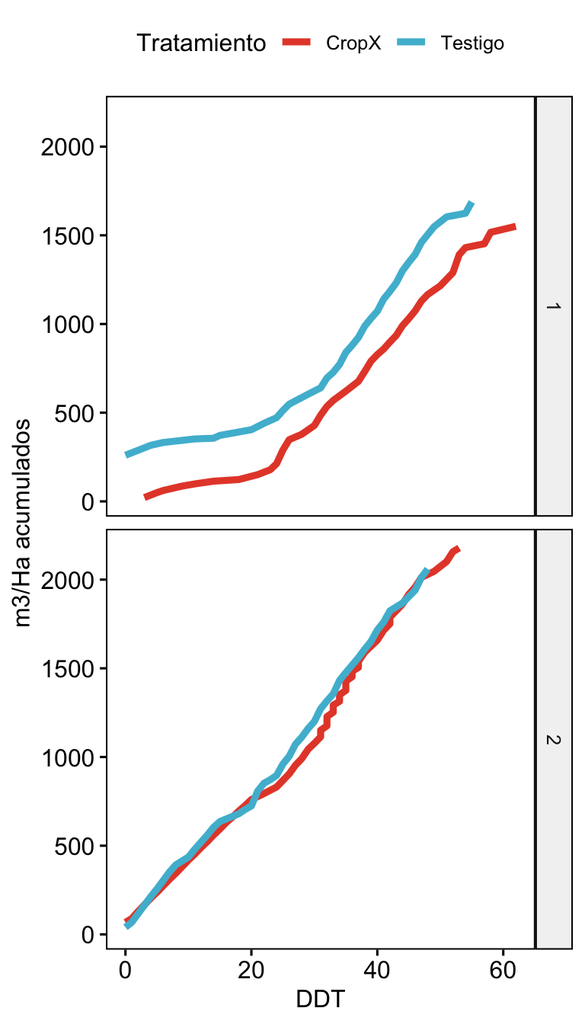

```r
    rgo_tfg %>% ggline(x="DDT",y="cum.m3", col="Tratamiento",palette = "npg",ggtheme = theme_pubr(border = TRUE), plot_type = "l", size = 1.618)+facet_grid(rows = vars(Siembra))+ylab("m3/Ha acumulados")
```